# Dynamic Report of Phone Users on AT buses

*This report analyses the usage of mobile devices on public transport around Auckland(primarily AT).*

The data collected included categorical variables for measuring time of data collection as well as nature of the days(Weekdays or Weekends) that the data was collected in. Numerical variables was also collected in proportions to identify phone users in the public transport.

The statistical graph below identifies the proportion of phone users during bus rides

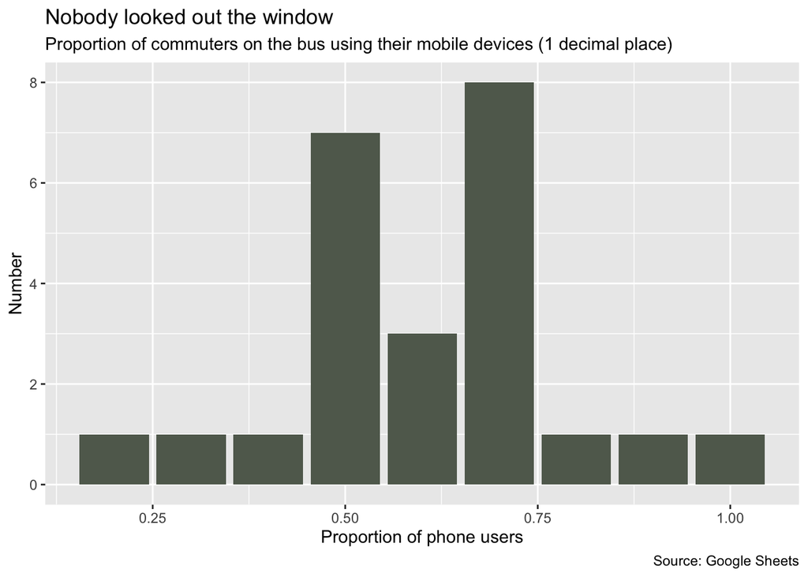

*Note: The above graph rounds the value of proportions to 1 decimal place for ease of understanding and may not reflect the exact value*

The mean value of 0.6 highlights that on average 60% of public transport commuters use their phones on a bus. The maximum value noted in our observation study showed a proportion of 0.98 highlighting 98% of commuters during said observation, while our minimum value of 0.2 highlight our lowest proportion of 20% of phone users.

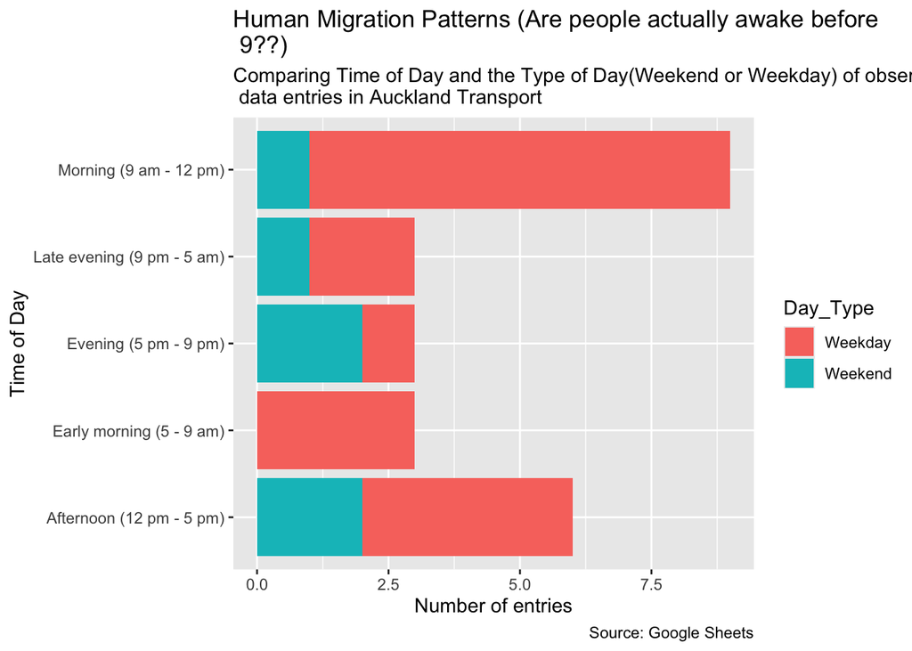

The above bar graph compares the time of day as well as the nature of the date(Weekdays or Weekends) that the data was collected in.

*The above graph provides a comprehensive view of the data collected to highlight plausible inaccuracies and fallacies.*